# Millipede Resolution

John Kirwan

2019-08-17

```r
options(mc.cores = parallel::detectCores())  # run all cores
Sys.setenv(LOCAL_CPPFLAGS = '-march=native') # for faster Stan execution
library('magrittr')
library('readr')
library('dplyr')
library('reshape2')
library('tibble')
library('CircStats')
library('circular')
library('ggplot2')
library('rstan')
rstan_options(auto_write = TRUE)
library('brms')
```

Load the data. The column stimulus_period refers to the period (intensity) of the stimulus at each observation; radian and degree are the headings taken by the animal from the centre in radians and degrees respectively. Batch referw to animals collected and tested in either 2018 or 2019.

```r
# df <- read_delim('Table S1.txt', delim = '\t')
df <- read_delim('millipede_extended.txt', delim = '\t')
df %>%
  mutate(batch = if_else(individual <= 100, '2018', '2019')) -> df
```

We represent the stimulus period and target half width angles in radians rather than degrees because the smaller (but still positive) values for the model predictor are preferable.

```r
df$stimulus_period  <- pi * df$stimulus_period / 180
df$target_halfwidth <- pi * df$target_halfwidth / 180
```

## Discretization

Here, we define the sector of the circle which we consider to be the ‘target’ region.

```r
df %>% mutate(success = 0) -> df
for(i in 1:length(df$radian)){df$success[i] <- NA}
for(i in 1:length(df$degree)){           ### get tote of each using one fifth of the circle
  if(is.na(df$degree[i]) == TRUE){df$success[i] <- 0}
  else if(df$degree[i] >   30) {df$success[i] <- 0}    ## pi/5 beforehand
  else if(df$degree[i] <= -30 ){df$success[i] <- 0}  ## -pi/5 beforehand
  else{df$success[i] <- 1}  }
```

Below, we make circular plots of the vectors for each of the treatments. Code borrowed and modified from James J. Foster, Lund Vision Group, Sweden (https://www.biology.lu.se/james-foster).

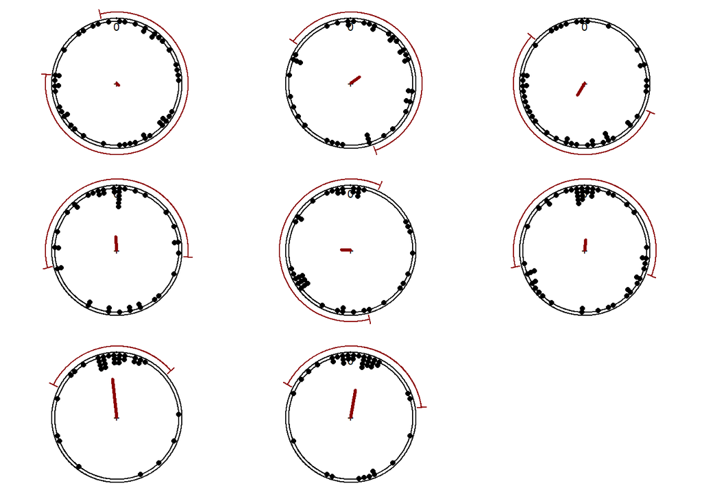

```r
stimulus_periodz <- levels(as.factor(df$stimulus_period)); stimulus_periodz.prop <- vector()
par(mfrow = c(3,ceiling(length(stimulus_periodz)/3)));
par(mar = c(0.5, 0.5, 0.5, 0.5) + 0.1) # bottom, left, top, right
j = 1;

mycirc <- function(angles, clock){
    if(missing(clock)){clock <- T}
    if(clock){
    return(
    as.circular(angles,
        units = 'degrees',
        type = 'angles', #don't set this to directions, apparently very different
        modulo = '2pi',
        zero = pi/2,
        rotation = 'clock',
        template = 'none')
        )
        }else{
        as.circular(angles,
        units = 'degrees',
        type = 'angles', #don't set this to directions, apparently very different
        modulo = '2pi',
        zero = pi/2,
        rotation = 'counter',
        template = 'none')
        }#if(clock)
}

CircCI <- function(mn, lci, uci, out, zro, drc, lng, ...){
    if(missing(lng)){lng <- 10*360/5} #bins #narrow them or they don't align with the actual angles!
    if(missing(drc)){drc <- 'clock'}
    if(missing(zro)){zro <- pi/2}
    #pi/2=start at screen top, pi=start at screen left, 3*pi/2=start at screen bottom, 0=start at sceen right
    if(missing(out)){out <- 0.05}
    if(missing(uci)){uci <- lci}
    lwr <- mn - lci
    upr <- mn + uci
    # if(lwr > 360){lwr <- lwr - 360}else{
        # if(lwr <0 ){lwr <- 360 - lwr}#if(lwr <0 )
    # }#if(lwr > 360)
    # if(upr > 360){upr <- upr - 360}else{
        # if(upr <0 ){upr <- 360 - upr}#if(upr <0 )
    # }#if(upr > 360)
    # print(paste('lower',lwr))
    # print(paste('upper',upr))
    circ.pos <- ( ((drc == 'clock')-1)*2 +1) * -seq( pi*lwr/180, pi*upr/180, length.out = lng) + zro
    circ.x <- cos(circ.pos)*(1+out)
    circ.y <- sin(circ.pos)*(1+out)
    lines(circ.x, circ.y, ...)
    lines.circular( as.circular(rep(lwr,2),units = 'degrees', type = 'angles', modulo = '2pi', zero = zro, rotation = drc, template = 'none'),
    out*c(0.5, 1.5), modulo = '2pi', zero = zro, rotation = drc, ...)
    lines.circular(as.circular(rep(upr,2),units = 'degrees', type = 'angles', modulo = '2pi', zero = zro, rotation = drc, template = 'none'),
    out*c(0.5, 1.5), modulo = '2pi', zero = zro, rotation = drc, ...)
}


Cplot <- function(headings, sp, bt, ax, ...){
    if(missing(ax)){ax <- F} #fit mean axis, fits mean direction unless otherwise specified
    #spacing of stacked points, now automatically stacks towards centre unless otherwise specified
    if(missing(sp) & missing(bt)){sp <- 0.04}
    #bt specifies the stacking by a multipicative factor, 1 = stacked, 2 = 1 point's space between, 0.5 = half overlapping
    if( missing(sp) & !(missing(bt)) ){sp <- bt*.04}
    #   Get functions and packages
    if(sum(rownames(installed.packages()) %in% c('CircStats', 'circular'), na.rm = T)<2){
        install.packages(c('CircStats', 'circular'))    }
    if(!(   sum('CircCI'%in% ls())  )){
        CircCI <- function(mn, lci, uci, out, zro, drc, lng, ...){
            if(missing(lng)){lng<-10*360/5};    if(missing(drc)){drc<-'clock'}
            if(missing(zro)){zro <- pi/2};if(missing(out)){out <- 0.05}
            if(missing(uci)){uci <- lci}
            lwr <- mn - lci;    upr <- mn + uci
            circ.pos <- ( ((drc == 'clock')-1)*2 +1) *
                -seq( pi*lwr/180, pi*upr/180, length.out = lng) + zro
            circ.x <- cos(circ.pos)*(1+out);    circ.y <- sin(circ.pos)*(1+out)
            lines(circ.x, circ.y, ...)
            lines.circular( as.circular(rep(lwr,2),units = 'degrees',
                type = 'angles', modulo = '2pi', zero = zro,
                rotation = drc, template = 'none'),
                out*c(0.5, 1.5), modulo = '2pi',
                zero = zro, rotation = drc, ...)
            lines.circular(as.circular(rep(upr,2),units = 'degrees',
                type = 'angles', modulo = '2pi', zero = zro,
                rotation = drc, template = 'none'),
                out*c(0.5, 1.5), modulo = '2pi', zero = zro,
                rotation = drc, ...)        }   }
    if(!(   sum('mycirc'%in% ls())  )){
        mycirc <- function(angles, clock){
            if(missing(clock)){clock <- T}
            if(clock){
            return(     as.circular(angles,units='degrees',type='angles',
            modulo='2pi',zero=pi/2,rotation='clock',    template='none')    )
                }else{
                as.circular(angles,units='degrees',type='angles',
                 modulo='2pi',zero=pi/2,rotation='counter',template='none')
                }   }   }
    #circular plot settings
    increments <- 5 #degrees
    zr <- pi/2 #start at top of screen (pi* 90  /180)
    bn <-  72  #10*10*360/5 #bins
    degrad <- 180/pi #conversion from radians to degrees
    tcl <- rgb(1,1,1,0)#transparent colour
    pcl <- rgb(.3,.1,.1,.5)#point colour
    #plot characters
    lw <- 0.5 #line width
    pnt <- 3 # 2.5 #point size
    arw <- 10 #arrowhead angle
    arl <- 0 #0.1 #arrowhead length
    #   set up input variables
    hd <- mycirc(headings)
    sm <- summary(hd)
    sv <- degrad*sd.circular(hd, na.rm=T)
    lbl <- 0 # 90*(1:4-1)
    plot(hd, col=tcl, main="", zero=zr, axes=F, shrink=1,tol=0.075)
    axis.circular(1, at = mycirc(lbl), labels = lbl)
    par(new=T)
    plot.circular(hd, col=tcl,main="",zero=zr,axes=F,shrink=1.05,tol=0.075)
    points(hd,stack=T,bin=bn,sep=-sp,zero=zr,...)
    if(!(ax)){
        arrows.circular( mycirc(sm['Mean']),zero=zr,col='red4',lwd=3,
         length=arl,angle=arw,shrink = sm['Rho'])
         CircCI(sm['Mean'], sv, out = 0.15, zro=zr, drc='clock',col='red4',lwd=1)   }else{
         sm2 <- summary(mycirc(hd*2))
         sv2 <- degrad*sd.circular(hd*2, na.rm=T)/2
         arrows.circular( mycirc(sm2['Mean']/2),zero=zr,col='red4',lwd=3,
         length=arl,angle=arw,shrink = sm2['Rho'])
         arrows.circular( mycirc(180+sm2['Mean']/2),zero=zr,col='red4',lwd=3,
         length=arl,angle=arw,shrink = sm2['Rho'])
         CircCI(sm2['Mean']/2, sv2, out = 0.15, zro=zr, drc='clock',col='red4',lwd=1)
         CircCI(180+sm2['Mean']/2, sv2, out = 0.15, zro=zr, drc='clock',col='red4',lwd=1)
     } }#if(!(ax))

for(i in stimulus_periodz){
    Cplot(df$degree[df$stimulus_period==i],0.06)#,
         # lci= mle.vonmises.bootstrap.ci(df$degree[df$stimulus_period==i])$mu.ci[1],
         #  uci= mle.vonmises.bootstrap.ci(df$degree[df$stimulus_period==i])$mu.ci[1] )
    stimulus_periodz.prop[j] <- sum(df$success[df$stimulus_period==i])/length(df$success[df$stimulus_period==i])
    j <- j + 1  }
```

Have a look at what happens with differing stimulus_period width of the target, to get an impression of the response and to see if the result is likely to be robust to changes in the stimulus_period width.

```r
df %>% as_tibble %>%                 # dataframe name
  mutate(in.quad = ifelse(abs(radian) < pi/4, 1, 0)) %>% # for data in radians -pi to pi
  mutate(in.pent = ifelse(abs(radian) < pi/5, 1, 0)) %>% # for data in radians -pi to pi
  mutate(in.sext = ifelse(abs(radian) < pi/6, 1, 0)) %>% # for data in radians -pi to pi
  mutate(in.oct = ifelse(abs(radian) < pi/8, 1, 0))  %>% # for data in radians -pi to pi
  group_by(stimulus_period) %>%                # condition name
  summarize(target = round(target_halfwidth * 180 / pi)[1],
            n_obs = n(),                   ## observations for treatment
            uniq_ind = n_distinct(individual),    ## unique individuals by treatment
            mu = round(180*mean.circular(radian)/pi,0),
            lo.ci = round(180*mle.vonmises.bootstrap.ci(radian)$mu.ci[1]/pi),
            hi.ci = round(180*mle.vonmises.bootstrap.ci(radian)$mu.ci[2]/pi),
            rho = round(rho.circular(radian),2),
            kappa = unlist(mle.vonmises(radian)[3]),
            v.stat =unlist(rayleigh.test(radian,mu=0)[1]),
            v.p= unlist(rayleigh.test(radian,mu=0)[2]),
            rayl.stat=unlist(rayleigh.test(radian)[1]),
            rayl.p= unlist(rayleigh.test(radian)[2]),
            c.mean = unlist(mean.circular(radian)[1]),
            quad.prop = sum(in.quad)/length(in.quad),
            pent.prop = sum(in.pent)/length(in.pent),
            sext.prop = sum(in.sext)/length(in.sext),
            oct.prop = sum(in.oct)/length(in.oct),
            binom.p = unlist(
                binom.test(sum(in.sext),length(in.sext),
                p=1/6,alternative = "greater")[3])) -> circ_fun_facts      ## output dataframe
circ_fun_facts
```

```
## # A tibble: 8 x 19
##   stimulus_period target n_obs uniq_ind mu    lo.ci hi.ci   rho  kappa
##             <dbl>  <dbl> <int>    <int> <cir> <cir> <cir> <dbl>  <dbl>
## 1           0          0    47       47  132   -24  305    0.04 0.0793
## 2           0.244      5    41       41   53   -30  182    0.17 0.355
## 3           0.489     10    44       44 -148  -201  -83    0.23 0.462
## 4           0.733     15    42       42   -4   -76   68    0.22 0.454
## 5           0.977     20    42       42  -86  -160   21    0.16 0.325
## 6           1.48      30    52       52    4   -74   89    0.17 0.353
## 7           1.97      40    33       33   -7   -24    8    0.62 1.60
## 8           2.46      50    39       39   10    -9   35    0.45 1.01
## # ... with 10 more variables: v.stat <dbl>, v.p <dbl>, rayl.stat <dbl>,
## #   rayl.p <dbl>, c.mean <circular>, quad.prop <dbl>, pent.prop <dbl>,
## #   sext.prop <dbl>, oct.prop <dbl>, binom.p <dbl>
```

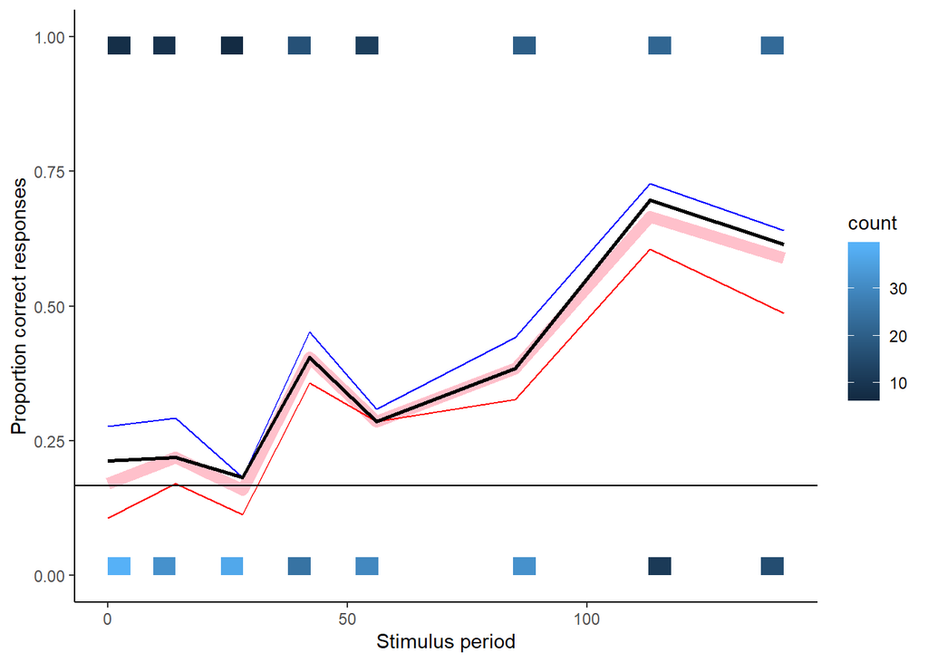

```r
circ_fun_facts %>%
  ggplot(aes(180*stimulus_period/pi, sext.prop)) + geom_line(color="pink",size=3)  + ylab("Proportion correct responses") +
  theme_classic() + xlab("Stimulus period") +  ## data in target quadrant
  geom_line(aes(y=oct.prop), color="red")   +                            ## data in target octant
  geom_line(aes(y=quad.prop), color="blue")        +                       ## data in target octant
   geom_line(data=circ_fun_facts,aes(x=180*stimulus_period/pi , y=pent.prop),size=1) +
   geom_hline(yintercept = 1/6) +
   geom_bin2d(data=df,aes(y = success, x = 180*stimulus_period/pi)) # counts
```

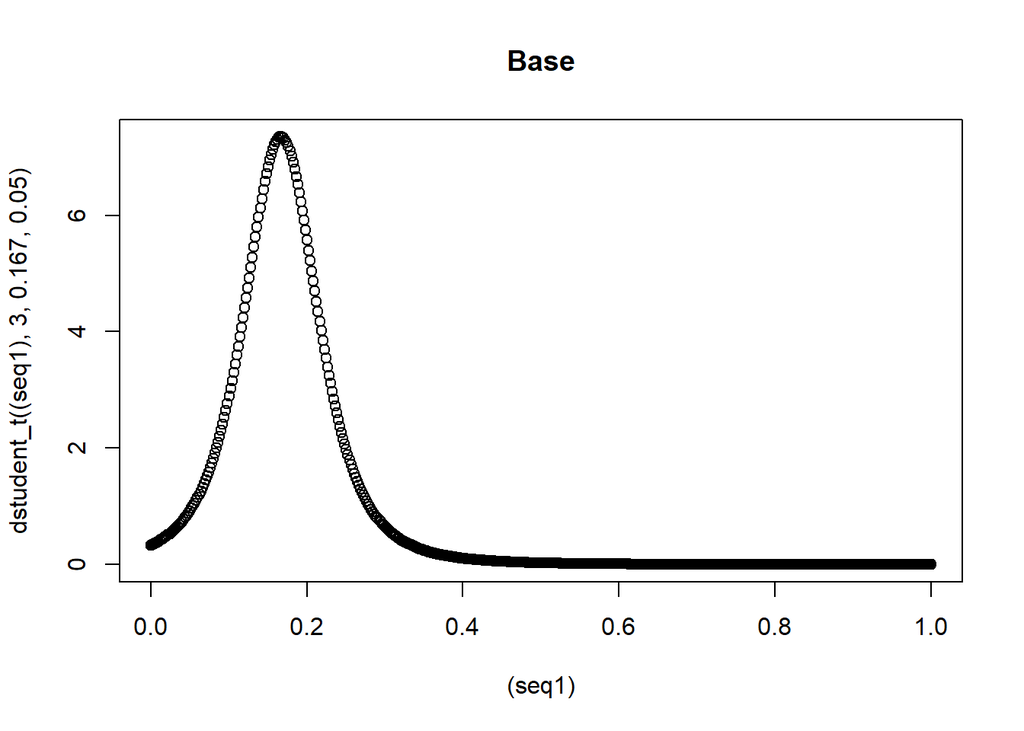

```r
seq1 <- seq(from=0,to=1, length.out = 500)
seq3 <- seq(from=-4.5,to=4.5,length.out = 500)
plot((seq1),dstudent_t((seq1), 3, 0.167,0.05), main="Base")
```

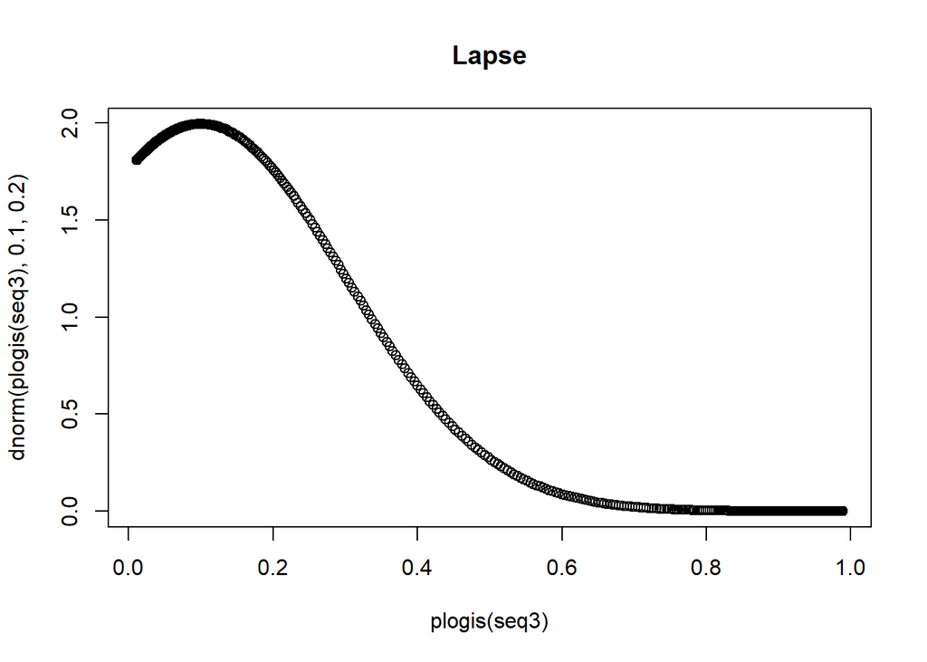

```r
plot(plogis(seq3),dnorm(plogis(seq3), 0.1,0.2), main="Lapse")
```

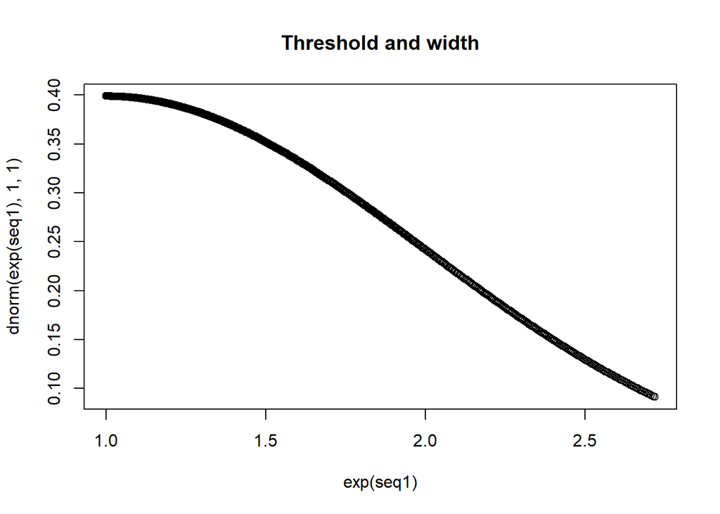

```r
plot(exp(seq1),dnorm(exp(seq1), 1,1),main="Threshold and width")
```

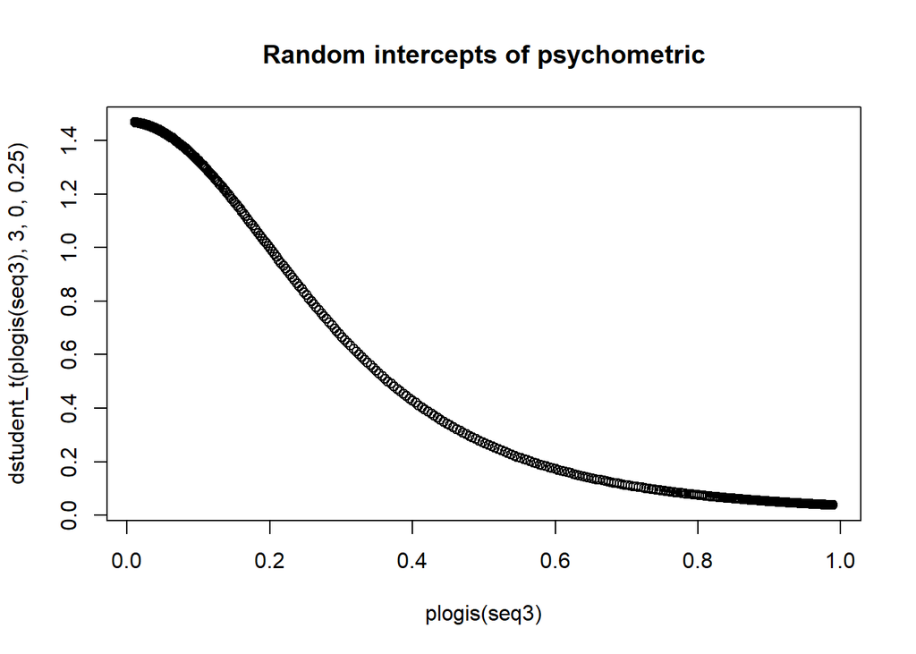

```r
plot(plogis(seq3),dstudent_t(plogis(seq3), 3, 0,0.25),main="Random intercepts of psychometric")
```

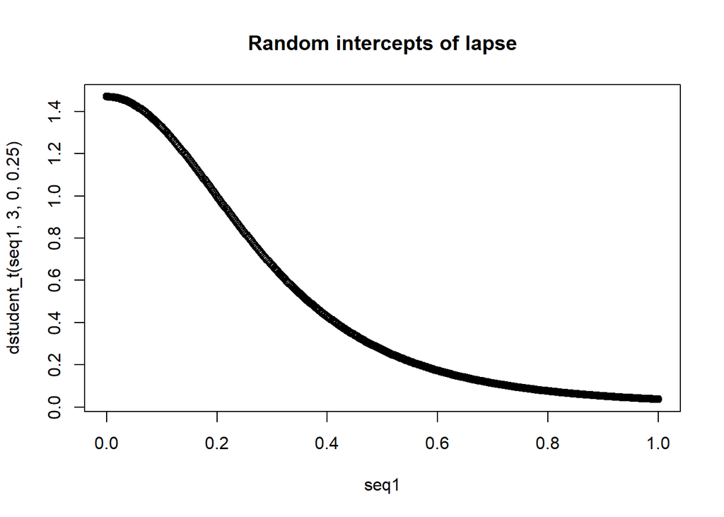

```r
plot(seq1,dstudent_t(seq1, 3, 0,0.25),main="Random intercepts of lapse")
```